# Visualizing time series

# Import libraries and define options

```r
library(dplyr)
library(reshape2)
library(chron)
library(ggplot2)
```

```r
source("GRB001.R")
```

Define options

```r
Sys.setlocale("LC_TIME","C")
options(stringsAsFactors=FALSE)
options(chron.year.abb=FALSE)
theme_set(theme_bw()) # just my preference for plots
```

# Load data

Based on past work, we can define a function that reads in the data and additionally provides several time variables.

R provides many functions for extraction of time information, but for atmospheric applications we often classify time periods according to season (which is not provided). We will define our own function to convert month to season:

```r
Month2Season <- function(month) {
  seasons <- c("DJF", "MAM", "JJA", "SON")
  index <- findInterval(month %% 12, seq(0, 12, 3))
  factor(seasons[index], seasons)
}
```

Test this new function:

```r
Month2Season(c(1, 3, 12))
```

```
## [1] DJF MAM DJF
## Levels: DJF MAM JJA SON
```

Next, we define the function for importing the time series:

```r
ReadTSeries <- function(filename, timecolumn="datetime", timeformat="%d.%m.%Y %H:%M") {
  ## read the table
  data <- read.table(filename, skip=5, header=TRUE, sep=";", check.names=FALSE)
  names(data) <- sub("[ ].*$","",names(data)) # strip units for simplification
  names(data) <- sub("Date/time", timecolumn, names(data), fixed=TRUE)
  data[,timecolumn] <- as.chron(data[,timecolumn], timeformat) - 1/24 # end time -> start time
  ## additional variables
  data[,"year"] <- years(data[,timecolumn])
  data[,"month"] <- months(data[,timecolumn])
  data[,"day"] <- days(data[,timecolumn])
  data[,"hour"] <- hours(data[,timecolumn])
  data[,"dayofwk"] <- weekdays(data[,timecolumn])
  data[,"daytype"] <- ifelse(data[,"dayofwk"] %in% c("Sat","Sun"), "Weekend", "Weekday")
  data[,"season"] <- Month2Season(unclass(data[,"month"]))
  ## avoid package conflict (for version installed in GRB001)
  data[,timecolumn] <- c(unclass(data[,timecolumn]))
  ## return value
  data
}
```

Read and merge Lausanne (LAU) and Zürich (ZUE) data:

```r
datapath <- "data/2013"

df <- full_join(cbind(site="LAU", ReadTSeries(file.path(datapath, "LAU.csv"))),
                cbind(site="ZUE", ReadTSeries(file.path(datapath, "ZUE.csv"))))
```

We can see that this data frame contains data from both sites.

```r
head(df)
```

```
##   site datetime   O3  NO2  CO PM10 TEMP PREC  RAD year month day hour
## 1  LAU 15705.00  7.8 56.3 0.5 16.1  3.8    0 -2.4 2012   Dec  31    0
## 2  LAU 15705.04 22.4 38.0 0.4 11.6  4.1    0 -2.3 2012   Dec  31    1
## 3  LAU 15705.08 14.5 37.2 0.3 10.3  3.1    0 -2.1 2012   Dec  31    2
## 4  LAU 15705.12 28.7 25.4 0.3 10.5  3.5    0 -2.2 2012   Dec  31    3
## 5  LAU 15705.17 19.6 33.7 0.3  9.0  2.9    0 -2.2 2012   Dec  31    4
## 6  LAU 15705.21 30.8 51.2 0.3  8.7  3.2    0 -2.3 2012   Dec  31    5
##   dayofwk daytype season SO2 NMVOC EC
## 1     Mon Weekday    DJF  NA    NA NA
## 2     Mon Weekday    DJF  NA    NA NA
## 3     Mon Weekday    DJF  NA    NA NA
## 4     Mon Weekday    DJF  NA    NA NA
## 5     Mon Weekday    DJF  NA    NA NA
## 6     Mon Weekday    DJF  NA    NA NA
```

```r
tail(df)
```

```
##       site datetime  O3  NO2  CO PM10 TEMP PREC  RAD year month day hour
## 17563  ZUE 16070.75 1.4 49.1 0.6 28.5  1.0    0 -2.7 2013   Dec  31   18
## 17564  ZUE 16070.79 1.5 47.9 0.6 31.9  0.2    0 -2.4 2013   Dec  31   19
## 17565  ZUE 16070.83 2.0 48.6 0.7 34.1 -0.1    0 -2.5 2013   Dec  31   20
## 17566  ZUE 16070.88 2.5 48.4 0.7 40.7  0.0    0 -2.4 2013   Dec  31   21
## 17567  ZUE 16070.92 2.2 43.0 0.6 48.5 -0.4    0 -2.5 2013   Dec  31   22
## 17568  ZUE 16070.96 2.4 43.5 0.6 53.3 -0.7    0 -2.5 2013   Dec  31   23
##       dayofwk daytype season SO2 NMVOC  EC
## 17563     Tue Weekday    DJF 3.4   0.2 2.4
## 17564     Tue Weekday    DJF 3.4   0.2 2.4
## 17565     Tue Weekday    DJF 3.3   0.2 2.6
## 17566     Tue Weekday    DJF 4.2   0.2 2.6
## 17567     Tue Weekday    DJF 3.6   0.2 2.5
## 17568     Tue Weekday    DJF 4.4   0.2 2.5
```

Let us save this data frame for later.

```r
saveRDS(df, "data/2013/lau-zue.rds")
```

Elongate the data frame, as before.

```r
lf <- melt(df, id.vars=c("site", "datetime", "season", "year", "month", "day", "hour", "dayofwk", "daytype"))
```

# View variability in pollutant concentrations

Plotting your data is very good practice. Check for general trends and extreme values.

View all the measurements:

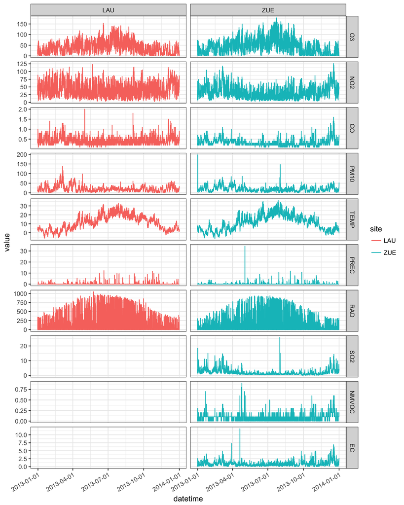

```r
ggp <- ggplot(lf)+
  facet_grid(variable~site, scale="free_y")+
  geom_line(aes(datetime, value, color=site))+
  scale_x_chron()+
  theme(axis.text.x=element_text(angle=30, hjust=1))
print(ggp)
```

In the following figures, we will summarize the measurements using non-parametric (order) statistics, which we will cover in a subsequent lecture.

## Seasonal variations

Summary by month:

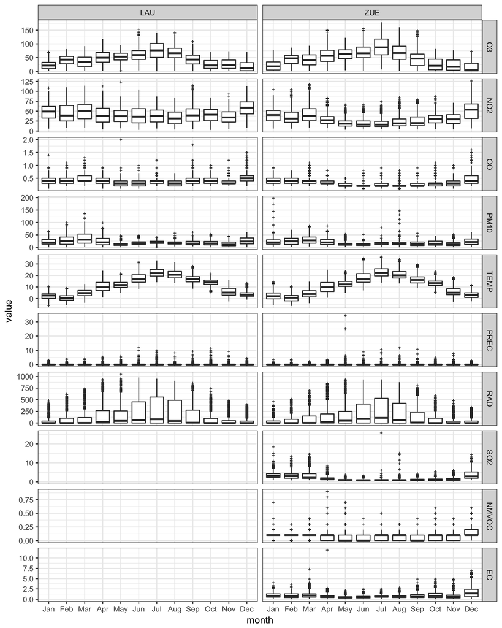

```r
ggp <- ggplot(lf) +
  facet_grid(variable ~ site, scale = "free_y") +
  geom_boxplot(aes(month, value), outlier.size = 0.5, outlier.shape = 3)
print(ggp)
```

By day type and season:

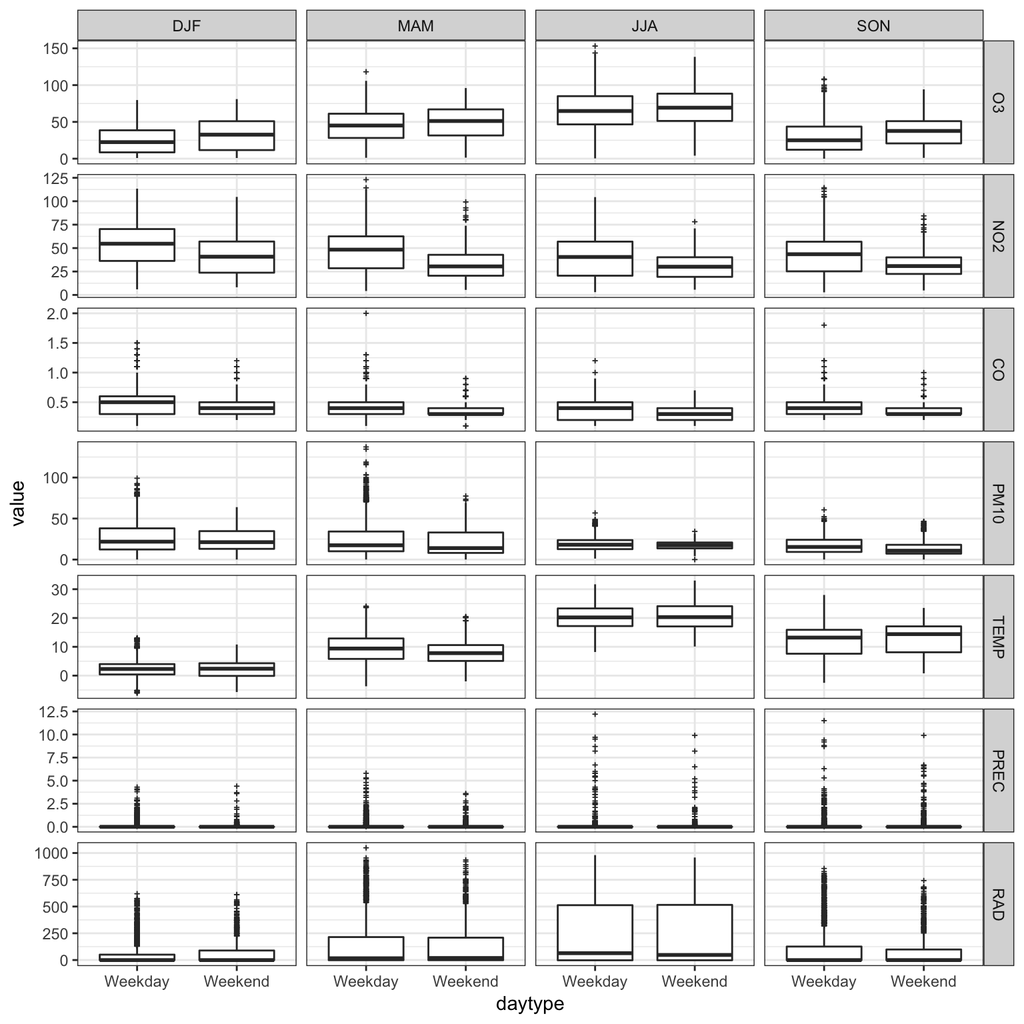

```r
ggp <- ggplot(lf %>% filter(site=="LAU" & !is.na(value))) +
  facet_grid(variable ~ season, scale = "free_y") +
  geom_boxplot(aes(daytype, value), outlier.size = 0.5, outlier.shape = 3)
print(ggp)
```

## Diurnal variations

The following function returns a function to be used for calculation of error bars.

```r
Percentile <- function(perc)
  function(x) quantile(x, perc*1e-2, na.rm=TRUE)
```

Diurnal (hourly) variations in pollutant concentrations at Lausanne site:

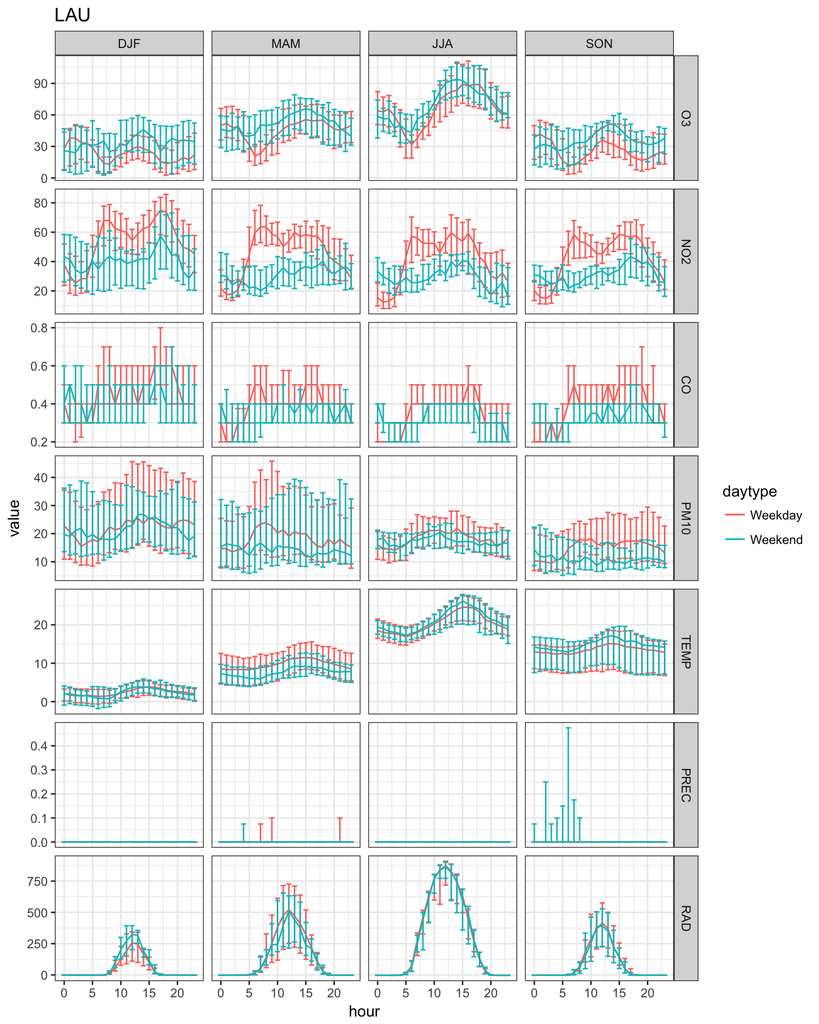

```r
ggp <- ggplot(data=lf %>% filter(site=="LAU" & !is.na(value)),
              mapping=aes(x=hour, y=value, group=daytype, color=daytype)) +
  facet_grid(variable ~ season, scale = "free_y", drop=TRUE) +
  geom_line(stat="summary", fun.y="median")+
  geom_errorbar(stat="summary",
                fun.ymin=Percentile(25),
                fun.ymax=Percentile(75))+
  ggtitle("LAU")
print(ggp)
```

Diurnal variations in O_3 concentrations:

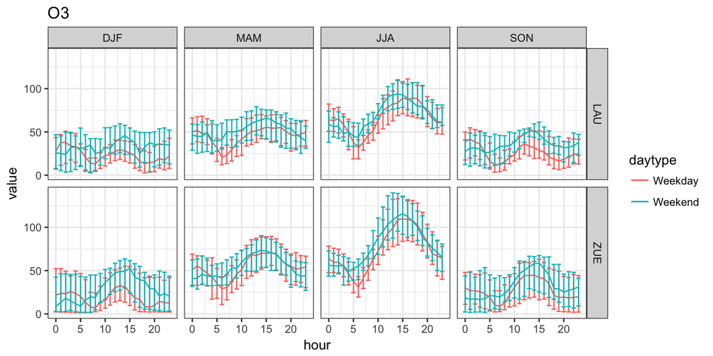

```r
ggp <- ggplot(data=lf %>% filter(variable=="O3"),
              mapping=aes(x=hour, y=value, group=daytype, color=daytype)) +
  facet_grid(site ~ season, drop=TRUE) +
  geom_line(stat="summary", fun.y="median")+
  geom_errorbar(stat="summary",
                fun.ymin=Percentile(25),
                fun.ymax=Percentile(75))+
  ggtitle("O3")
print(ggp)
```

Note that for concentrations of the same pollutant, we fix the y-scale to be the same for both rows.

Diurnal variations in NO_2 concentrations:

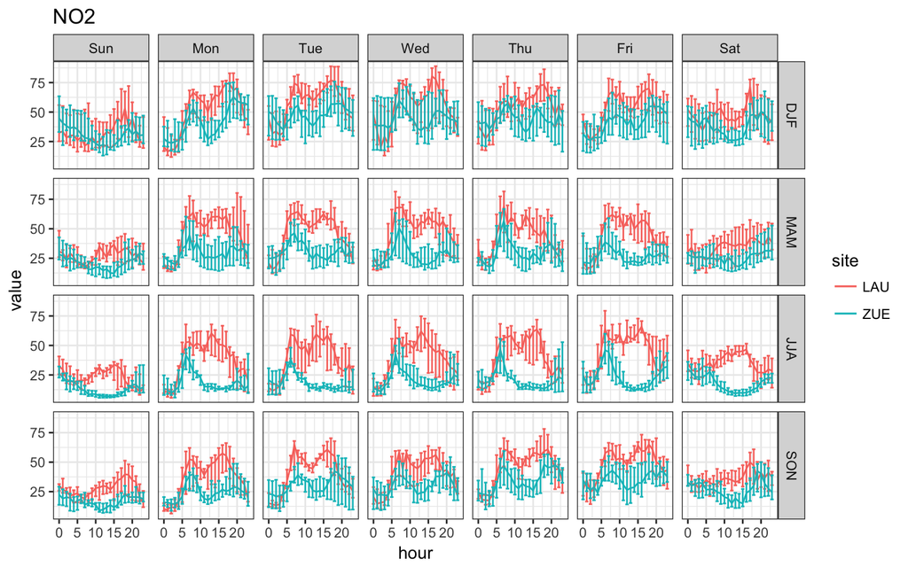

```r
ggp <- ggplot(data=lf %>% filter(variable=="NO2"),
              mapping=aes(x=hour, y=value, group=site, color=site)) +
  facet_grid(season ~ dayofwk, drop=TRUE) +
  geom_line(stat="summary", fun.y="median")+
  geom_errorbar(stat="summary",
                fun.ymin=Percentile(25),
                fun.ymax=Percentile(75))+
  ggtitle("NO2")
print(ggp)
```

Why are concentrations in Lausanne higher? (hint: check location of monitoring equipment)